# ForageModv02 Supplementary Analysis

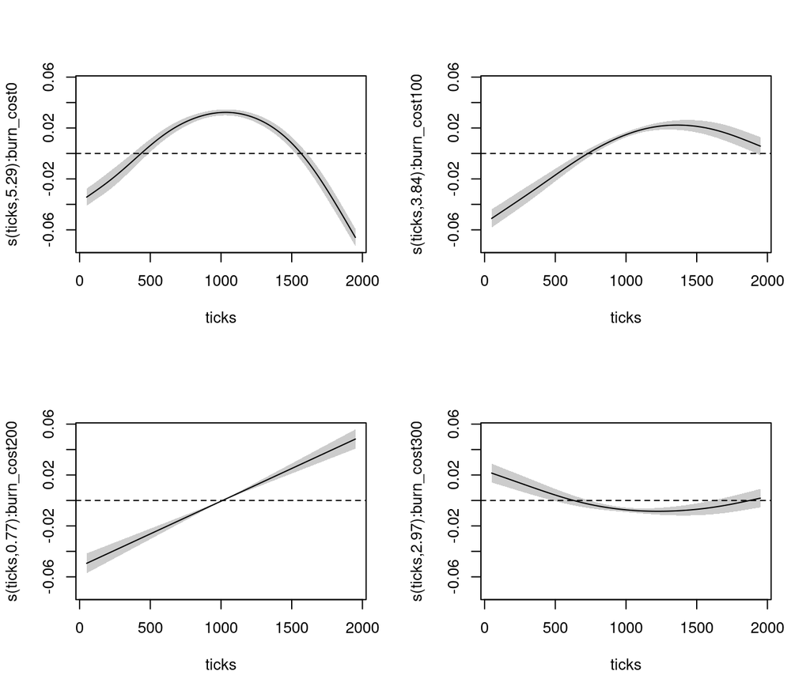

```r
par(mfrow=c(2,2), cex=0.8)
plot(dw.gam2, select=7, shade=T)
abline(h=0, lty = 2)
plot(dw.gam2, select=8, shade=T)
abline(h=0, lty = 2)
plot(dw.gam2, select=9, shade=T)
abline(h=0, lty = 2)
plot(dw.gam2, select=10, shade=T)
abline(h=0, lty = 2)
```

With directed walks, we can see that low and medium costs for burning behaviors have similar effects: at first negative, since burning is required to introduce new vegetation types, but then becoming positive as more burning is allowed to occur. We see a similar initial pattern with no burning costs; however, by the end of model run, the huge amount of burning leads to too many burnt patches that decreases the overall diversity of vegetation on the landscape. High burning cost has the opposite effect pattern, but a much more limited effect size. This is likely because high burning costs severely limits burning behaviors and therefore does not have a substantial impact on what vegetation types are available on the landscape.

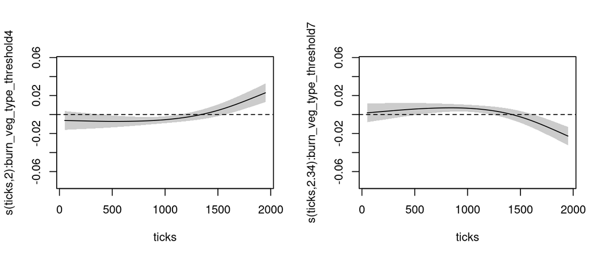

```r
par(mfrow=c(1,2), cex=0.8)
plot(dw.gam2, select=11, shade=T)
abline(h=0, lty = 2)
plot(dw.gam2, select=12, shade=T)
abline(h=0, lty = 2)
```

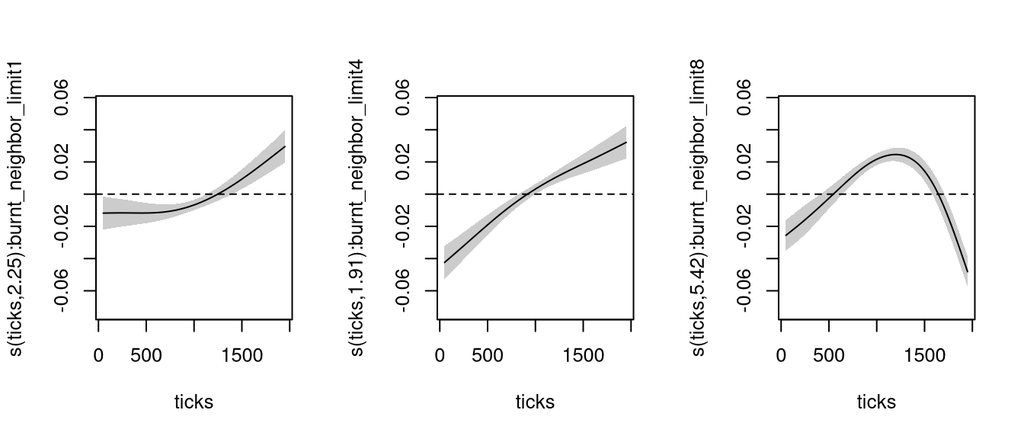

```r
par(mfrow=c(1,3), cex=0.8)
plot(dw.gam2, select=13, shade=T)
abline(h=0, lty = 2)
plot(dw.gam2, select=14, shade=T)
abline(h=0, lty = 2)
plot(dw.gam2, select=15, shade=T)
abline(h=0, lty = 2)
```

The limits on burning behaviors have more exaggerated effects with directed walks. We can again see clearly that more burning (with relaxed burning restrictions) reduces overall vegetation diversity by the end of model run.

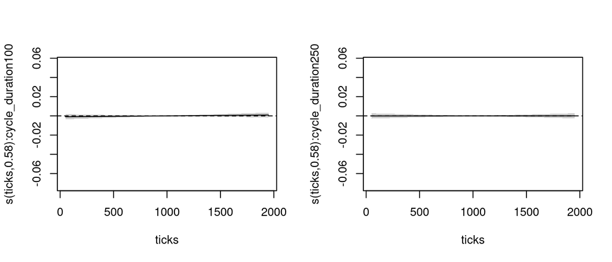

```r
par(mfrow=c(1,2), cex=0.8)
plot(dw.gam2, select=16, shade=T)
abline(h=0, lty = 2)
plot(dw.gam2, select=17, shade=T)
abline(h=0, lty = 2)
```

Cycle duration appears to have no effect on vegetation diversity with directed walks.

## Spatial distribution of burning events

Because burning behaviors have such a significant impact on the structure of the vegetation in the environment, we were curious if this is caused by differential use of space. To examine this, we looked at the spatial autocorrelation of where burning events occur within the landscape to assess land use by the agents. This analysis is split *cycle-duration.* We first use linear regressions to assess how the parameters and time affect the spatial autocorrelation of burning events. For this, we only consider significant values of Moran’s I to evaluate clustering (positive values) and dispersion (negative values).

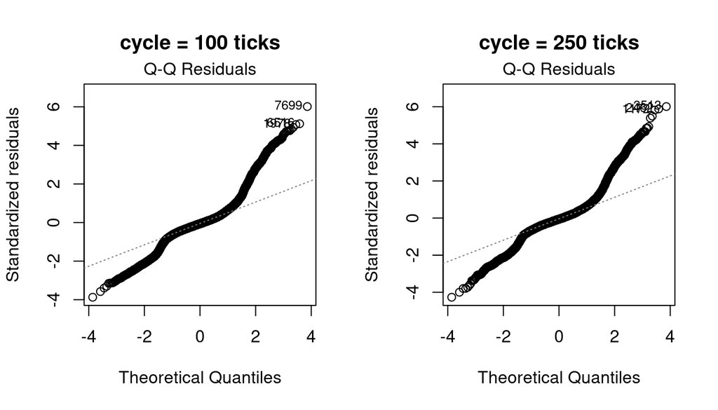

```
##   (Intercept)         ticks
##  8.567676e-02 -6.415679e-05
```

```
##   (Intercept)         ticks
##  8.388051e-02 -5.764522e-05
```

The intercept values show that, on average, burning events are on average marginally clustered on the landscape. This spatial autocorrelation is then significantly affected by time and, on average, decreases as model run progresses.

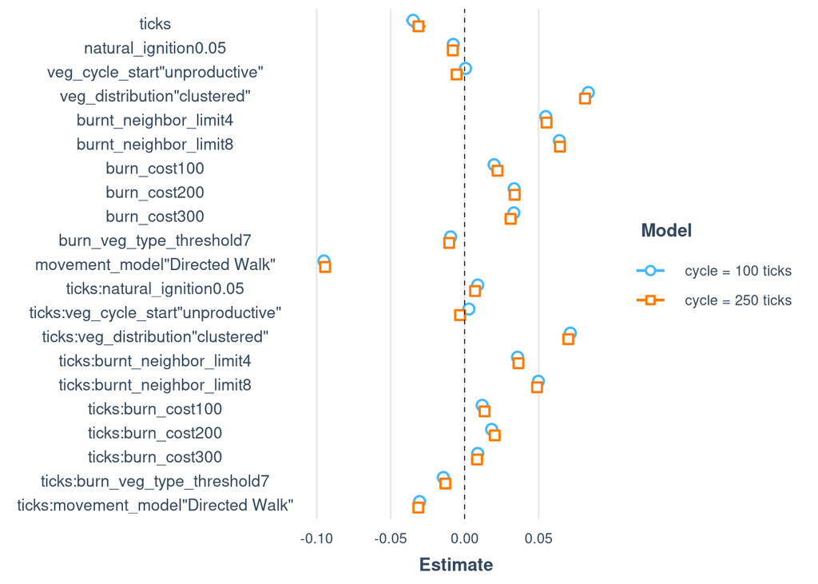

When looking at scaled regression coefficients, we can see that underlying distribution of resource potential (maximum veg type), burning limits, and movement models have the strongest effects on the spatial clustering of burning events. These strong effects are also maintained over time, as evidence by the high standardized regression coefficients for the interaction variables between these parameters and time). Importantly, time increase the effect size of these parameters in the same direction. For example, directed walks reduce the clustering of burning events on average and this effect is more negative with time.

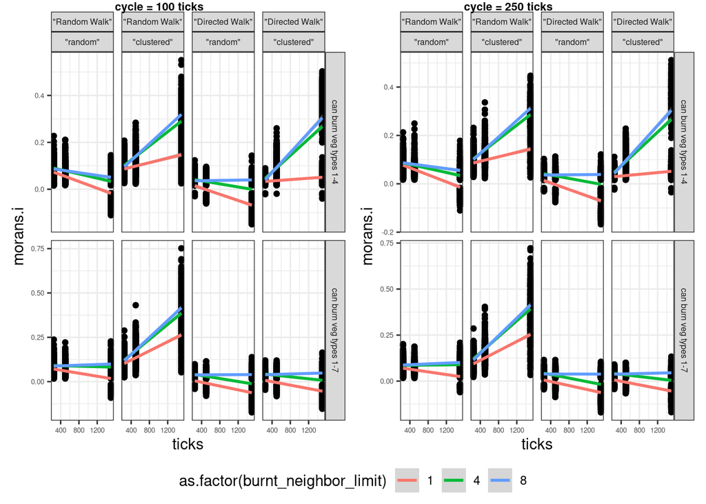

Plotting the trends of burning event spatial autocorrelation through time by these significant parameters allows us to better visualize these patterns. We can see that stricter limits on which patches can be burned typically result in dispersion of burning events (Moran’s I < 0). High clustering of burning events only occurs when the resource potential on the landscape is also clustered. However, as we can see in the above graph, this is also affected by other burning limits and movement models.

## Forager mobility

In the model, foragers adjust how many steps they take during a foraging bout if they determine they will meet their energy requirements with fewer steps. Movement in the model is, therefore, patterned primarily by the energy available in the gridded landscape, which is determined by whether the model is in a productive or unproductive climatic period and how long those climatic periods last.

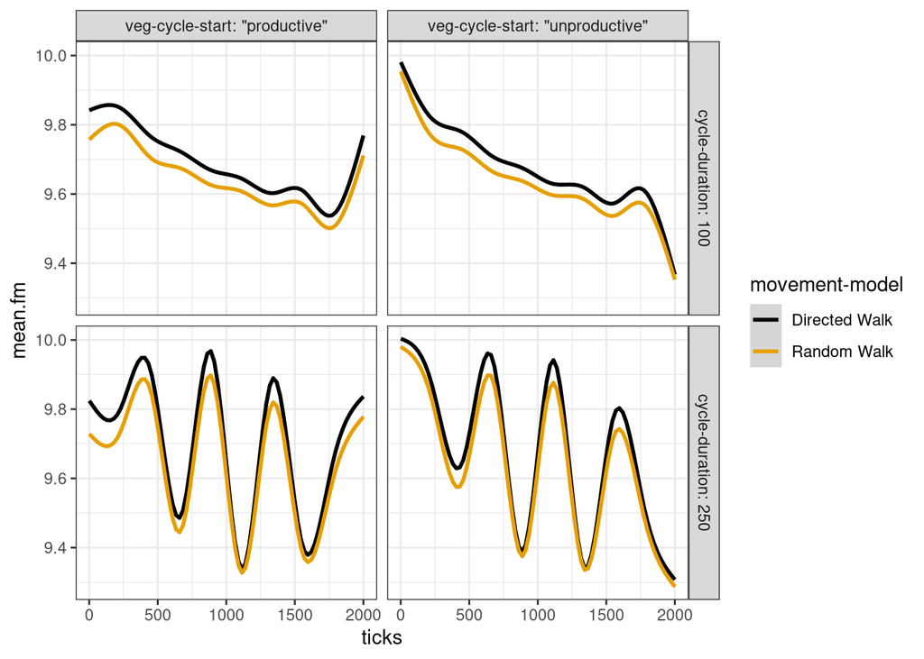

We can see from the above plot that there is a decrease in movement during productive periods and an increase in movement during unproductive periods of the model. This is more smoothed when cycle duration is shorter.

While cycle duration clearly causes fluctuations in agent movement behaviors, we chose to investigate average steps per foraging bout as a linear trend. Using mixed linear models, we can see how the other parameters affect forager movement while controlling for starting vegetation state to deal with the model end effects seen above.

```r
mm.fit1.1 = lmer(mean.fm ~ ticks + (1 | `veg-cycle-start`), data = data)

mm.fit1.2 = lmer(mean.fm ~ ticks + `movement-model` + `burnt-neighbor-limit` + `burn-cost` + `burn-veg-type-threshold` + `natural-ignition` + `cycle-duration` + `veg-distribution`+ (1 | `veg-cycle-start`),, data = data)

mm.fit1.3 = lmer(mean.fm ~ ticks*(`movement-model` + `burnt-neighbor-limit` + `burn-cost` + `burn-veg-type-threshold` + `natural-ignition`+ `cycle-duration` + `veg-distribution`) + (1 | `veg-cycle-start`), data = data)

mm.fit1.4 = lmer(mean.fm ~ ticks*(`movement-model` + `burnt-neighbor-limit` + `burn-cost` + `burn-veg-type-threshold` + `natural-ignition` + `veg-distribution`) + (1 | `veg-cycle-start`) + (1 | `cycle-duration`), data = data)

anova(mm.fit1.1, mm.fit1.2, mm.fit1.3, mm.fit1.4)
```

```
## Data: data
## Models:
## mm.fit1.1: mean.fm ~ ticks + (1 | `veg-cycle-start`)
## mm.fit1.2: mean.fm ~ ticks + `movement-model` + `burnt-neighbor-limit` + `burn-cost` + `burn-veg-type-threshold` + `natural-ignition` + `cycle-duration` + `veg-distribution` + (1 | `veg-cycle-start`)
## mm.fit1.4: mean.fm ~ ticks * (`movement-model` + `burnt-neighbor-limit` + `burn-cost` + `burn-veg-type-threshold` + `natural-ignition` + `veg-distribution`) + (1 | `veg-cycle-start`) + (1 | `cycle-duration`)
## mm.fit1.3: mean.fm ~ ticks * (`movement-model` + `burnt-neighbor-limit` + `burn-cost` + `burn-veg-type-threshold` + `natural-ignition` + `cycle-duration` + `veg-distribution`) + (1 | `veg-cycle-start`)
##           npar      AIC      BIC   logLik deviance      Chisq Df Pr(>Chisq)
## mm.fit1.1    4 11090096 11090154 -5545044 11090088
## mm.fit1.2   14  8690730  8690932 -4345351  8690702 2399386.27 10  < 2.2e-16 ***
## mm.fit1.4   23  8314449  8314782 -4157202  8314403  376298.53  9  < 2.2e-16 ***
## mm.fit1.3   24  8314412  8314759 -4157182  8314364      38.93  1  4.393e-10 ***
## ---
## Signif. codes:  0 '***' 0.001 '**' 0.01 '*' 0.05 '.' 0.1 ' ' 1
```

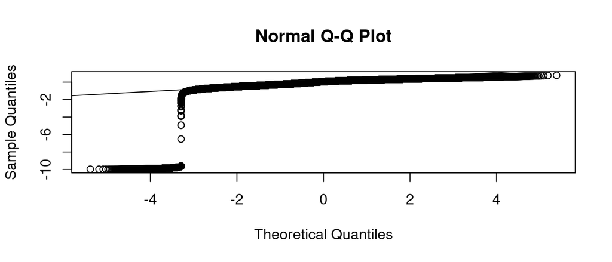

```r
qqnorm(resid(mm.fit1.3))
qqline(resid(mm.fit1.3))
```

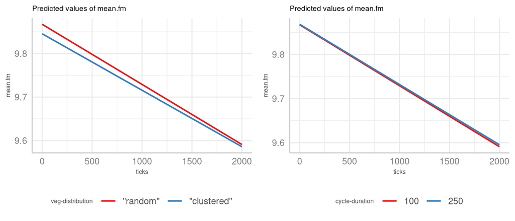

```r
ggpubr::ggarrange(
  ggeffects::ggpredict(mm.fit1.3, terms = c("ticks", "veg-distribution")) %>%
    plot(show_data = FALSE, show_ci = FALSE) +
    theme(title = element_text(size = 6), legend.title = element_text(size = 6)),
  ggeffects::ggpredict(mm.fit1.3, terms = c("ticks", "cycle-duration")) %>%
    plot(show_data = FALSE, show_ci = FALSE) +
    theme(title = element_text(size = 6), legend.title = element_text(size = 6)),
  legend = "bottom", nrow = 1
)
```

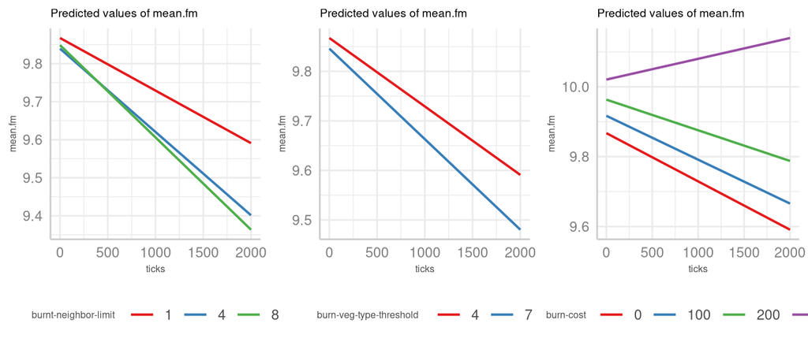

```r
ggpubr::ggarrange(
  ggeffects::ggpredict(mm.fit1.3, terms = c("ticks", "burnt-neighbor-limit")) %>%
    plot(show_data = FALSE, show_ci = FALSE) +
    theme(title = element_text(size = 6), legend.title = element_text(size = 6)),
  ggeffects::ggpredict(mm.fit1.3, terms = c("ticks", "burn-veg-type-threshold")) %>%
    plot(show_data = FALSE, show_ci = FALSE) +
    theme(title = element_text(size = 6), legend.title = element_text(size = 6)),
  ggeffects::ggpredict(mm.fit1.3, terms = c("ticks", "burn-cost")) %>%
    plot(show_data = FALSE, show_ci = FALSE) +
    theme(title = element_text(size = 6), legend.title = element_text(size = 6)),
  legend = "bottom", nrow = 1
)
```

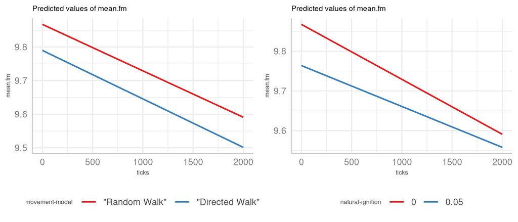

```r
ggpubr::ggarrange(
  ggeffects::ggpredict(mm.fit1.3, terms = c("ticks", "movement-model")) %>%
    plot(show_data = FALSE, show_ci = FALSE) +
    theme(title = element_text(size = 6), legend.title = element_text(size = 6)),
  ggeffects::ggpredict(mm.fit1.3, terms = c("ticks", "natural-ignition")) %>%
    plot(show_data = FALSE, show_ci = FALSE) +
    theme(title = element_text(size = 6), legend.title = element_text(size = 6)),
  legend = "bottom", nrow = 1
)
```

The regression model demonstrate that burning restrictions and burning costs have the greatest difference in impact on forager mobility. Stricter limits on burning behaviors and higher costs result in higher levels of mobility over the course of model run. Interestingly, the predicted mobility for the highest burning cost shows an increase in average moves per foraging bout. This pattern is impossible in the model because we cap mobility at a maximum value. The contrast of this with the other burning costs demonstrates the impact that low cost niche construction strategies can have on forager behaviors.

These mobility patterns due to different limits on burning behaviors occur because burning controls the energy available in the environment such that less burning means less overall energy, so agents need to move further to meet their energy needs.

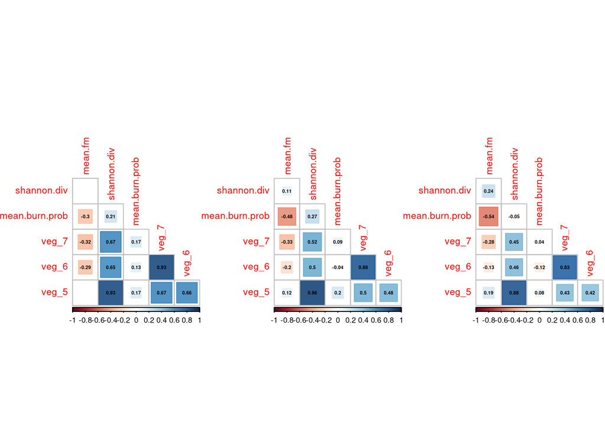

## Forager interactions

When looking at forager interactions, we have to consider them in relation to populations since more foragers on the landscape will necessarily mean more possible interactions. The model outputs interaction counts averaged across all agents and we divided this by the population count to get the average proportion of the population that an individual agent interacts with each tick.

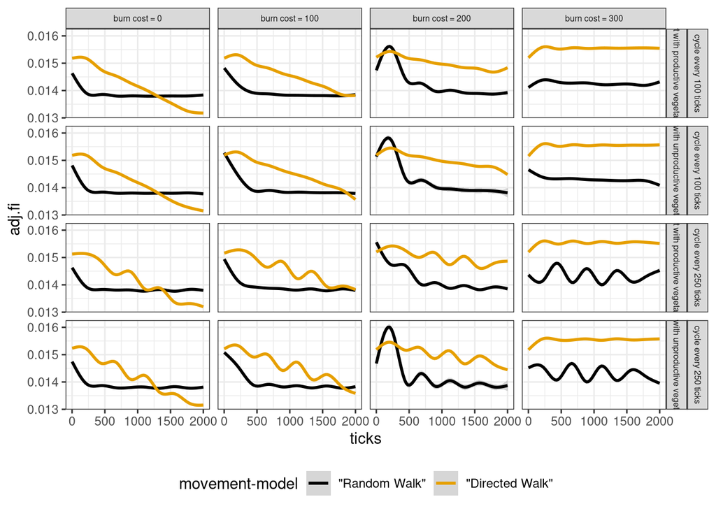

When we visualize these differences, we can see that for random walks, there is a steep drop off in forager interactions within approximately the first 500 ticks of the model. This is likely because populations are relatively small at the beginning of model run, so each interaction will necessarily be a greater proportion. For the subsequent analyses, we look at the patterns occurring after the first 500 ticks to understand how the parameters affect interactions after a larger population has been established.

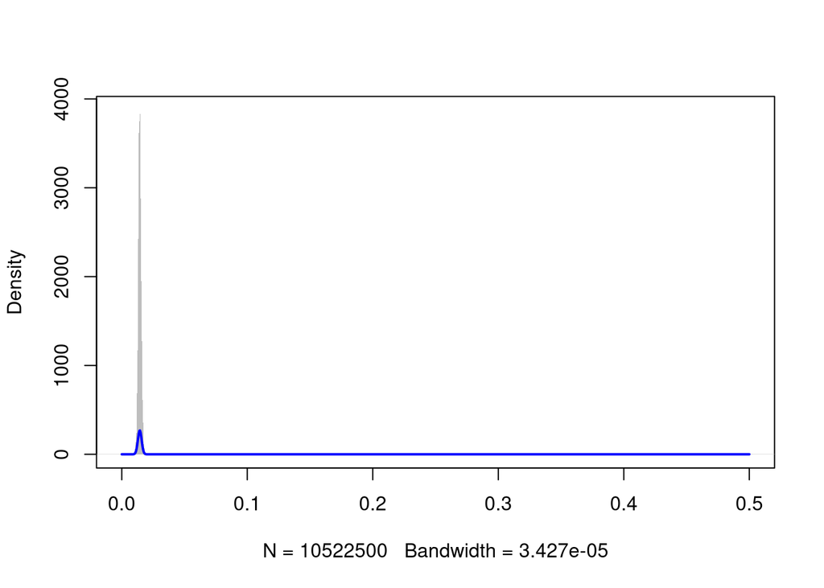

```r
fi.data = data %>% filter(ticks > 500)

plotNormalDensity(fi.data$adj.fi)
```

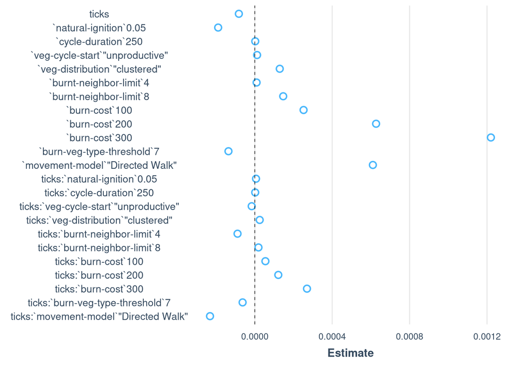

```r
parameters = c(
  "natural-ignition", # 0.00, 0.05
  "cycle-duration",  # 100, 250
  "veg-cycle-start", # productive, unproductive
  "veg-distribution", # random, clustered
  "burnt-neighbor-limit", # 1, 4, 8
  "burn-cost", # 0, 50
  "burn-veg-type-threshold", # 4, 7
  "movement-model" #Random, Directed
)

fi.fit1 = lm(adj.fi ~ ticks*(.), data = fi.data %>% dplyr::select_at(c(parameters, "ticks", "adj.fi")))

plot_summs(fi.fit1, scale = T)
```

By comparing standardized regression coefficients, we can see the greatest effect on forager interactions is movement models and burn cost. Because the shape of the trend lines is different enough between random walks and directed walks, we split the data by movement model to further investigate parameter effects.

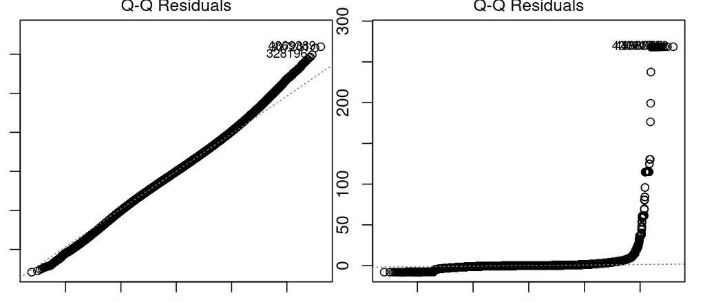

```r
rw.data = fi.data %>% filter(`movement-model` == "\"Random Walk\"")
dw.data = fi.data %>% filter(`movement-model` == "\"Directed Walk\"")

dw.fit1 = lm(adj.fi ~ ticks*(.), data = dw.data %>% filter(ticks > 0) %>% select_at(c("ticks", "adj.fi", parameters[-8])))

rw.fit1 = lm(adj.fi ~ ticks*(.), data = rw.data %>% filter(ticks > 0) %>% select_at(c("ticks", "adj.fi", parameters[-8])))

par(mfrow = c(1,2))
par(mar=c(1,1,1,1))
plot(dw.fit1, which = 2)
plot(rw.fit1, which = 2)
```

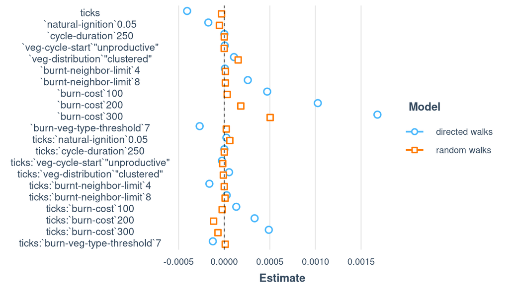

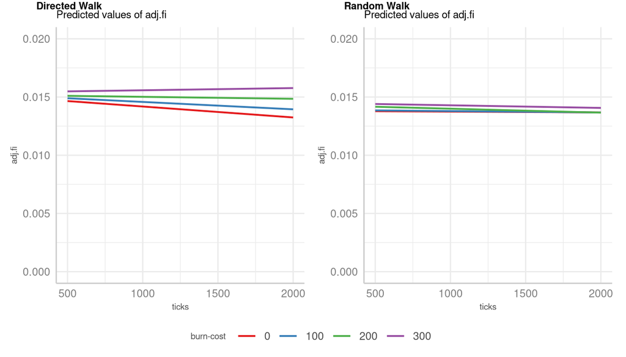

These two regressions demonstrate that restrictions/costs to burning behaviors impact forager interactions, but that these effects are much more prominent and diverging for directed walks. This again indicates that the amount of burning has a significant impact on the evolution of human behaviors in the model.

## References

| Package | Version | Citation |
| --- | --- | --- |
| base | 4.3.2 | (1) |
| betareg | 3.1.4 | (2); (3) |
| corrplot | 0.92 | (4) |
| fitdistrplus | 1.2.1 | (5) |
| formatR | 1.14 | (6) |
| ggeffects | 1.7.0 | (7) |
| ggpubr | 0.6.0 | (8) |
| ggsignif | 0.6.4 | (9) |
| ggspatial | 1.1.9 | (10) |
| ggthemes | 5.1.0 | (11) |
| grateful | 0.2.10 | (12) |
| grid | 4.3.2 | (13) |
| gtsummary | 1.7.2 | (14) |
| jtools | 2.2.2 | (15) |
| knitr | 1.45 | (16); (17); (18) |
| lme4 | 1.1.35.1 | (19) |
| lmerTest | 3.1.3 | (20) |
| mgcv | 1.9.1 | (21); (22); (23); (24); (25) |
| png | 0.1.8 | (26) |
| psych | 2.3.9 | (27) |
| rcompanion | 2.4.36 | (28) |
| rmarkdown | 2.25 | (29); (30); (31) |
| scales | 1.3.0 | (32) |
| segmented | 2.0.0 | (33); (34); (35); (36); (37); (38) |
| sp | 2.1.4 | (39); (40) |
| spdep | 1.3.5 | (41); (42); (43); (44) |
| tidyverse | 2.0.0 | (45) |
| vegan | 2.6.6.1 | (46) |

1.

R Core Team, *[R: A language and environment for statistical computing](https://www.R-project.org/)* (R Foundation for Statistical Computing, 2023).

2.

F. Cribari-Neto, A. Zeileis, [Beta regression in R](https://doi.org/10.18637/jss.v034.i02). *Journal of Statistical Software* **34**, 1–24 (2010).

3.

B. Grün, I. Kosmidis, A. Zeileis, [Extended beta regression in R: Shaken, stirred, mixed, and partitioned](https://doi.org/10.18637/jss.v048.i11). *Journal of Statistical Software* **48**, 1–25 (2012).

4.

T. Wei, V. Simko, *[R package “corrplot”: Visualization of a correlation matrix](https://github.com/taiyun/corrplot)* (2021).

5.

M. L. Delignette-Muller, C. Dutang, [fitdistrplus: An R package for fitting distributions](https://doi.org/10.18637/jss.v064.i04). *Journal of Statistical Software* **64**, 1–34 (2015).

6.

Y. Xie, *[formatR: Format r code automatically](https://CRAN.R-project.org/package=formatR)* (2023).

7.

D. Lüdecke, [ggeffects: Tidy data frames of marginal effects from regression models.](https://doi.org/10.21105/joss.00772) *Journal of Open Source Software* **3**, 772 (2018).

8.

A. Kassambara, *[ggpubr: “ggplot2” based publication ready plots](https://CRAN.R-project.org/package=ggpubr)* (2023).

9.

A.-E. Constantin, I. Patil, ggsignif: R package for displaying significance brackets for “ggplot2”. *PsyArxiv* (2021). https://doi.org/10.31234/osf.io/7awm6.

10.

D. Dunnington, *[ggspatial: Spatial data framework for ggplot2](https://CRAN.R-project.org/package=ggspatial)* (2023).

11.

J. B. Arnold, *[ggthemes: Extra themes, scales and geoms for “ggplot2”](https://CRAN.R-project.org/package=ggthemes)* (2024).

12.

F. Rodriguez-Sanchez, C. P. Jackson, *[grateful: Facilitate citation of r packages](https://pakillo.github.io/grateful/)* (2023).

13.

R Core Team, *[R: A language and environment for statistical computing](https://www.R-project.org/)* (R Foundation for Statistical Computing, 2023).

14.

D. D. Sjoberg, K. Whiting, M. Curry, J. A. Lavery, J. Larmarange, [Reproducible summary tables with the gtsummary package](https://doi.org/10.32614/RJ-2021-053). *The R Journal* **13**, 570–580 (2021).

15.

J. A. Long, *[jtools: Analysis and presentation of social scientific data](https://cran.r-project.org/package=jtools)* (2022).

16.

Y. Xie, “knitr: A comprehensive tool for reproducible research in R” in *Implementing Reproducible Computational Research*, V. Stodden, F. Leisch, R. D. Peng, Eds. (Chapman; Hall/CRC, 2014).

17.

Y. Xie, *[Dynamic documents with R and knitr](https://yihui.org/knitr/)*, 2nd Ed. (Chapman; Hall/CRC, 2015).

18.

Y. Xie, *[knitr: A general-purpose package for dynamic report generation in r](https://yihui.org/knitr/)* (2023).

19.

D. Bates, M. Mächler, B. Bolker, S. Walker, [Fitting linear mixed-effects models using lme4](https://doi.org/10.18637/jss.v067.i01). *Journal of Statistical Software* **67**, 1–48 (2015).

20.

A. Kuznetsova, P. B. Brockhoff, R. H. B. Christensen, [lmerTest package: Tests in linear mixed effects models](https://doi.org/10.18637/jss.v082.i13). *Journal of Statistical Software* **82**, 1–26 (2017).

21.

S. N. Wood, Thin-plate regression splines. *Journal of the Royal Statistical Society (B)* **65**, 95–114 (2003).

22.

S. N. Wood, Stable and efficient multiple smoothing parameter estimation for generalized additive models. *Journal of the American Statistical Association* **99**, 673–686 (2004).

23.

S. N. Wood, Fast stable restricted maximum likelihood and marginal likelihood estimation of semiparametric generalized linear models. *Journal of the Royal Statistical Society (B)* **73**, 3–36 (2011).

24.

S. N. Wood, N., Pya, B. S"afken, Smoothing parameter and model selection for general smooth models (with discussion). *Journal of the American Statistical Association* **111**, 1548–1575 (2016).

25.

S. N. Wood, *Generalized additive models: An introduction with r*, 2nd Ed. (Chapman; Hall/CRC, 2017).

26.

S. Urbanek, *[png: Read and write PNG images](https://CRAN.R-project.org/package=png)* (2022).

27.

William Revelle, *[psych: Procedures for psychological, psychometric, and personality research](https://CRAN.R-project.org/package=psych)* (Northwestern University, 2023).

28.

S. S. Mangiafico, *[rcompanion: Functions to support extension education program evaluation](https://CRAN.R-project.org/package=rcompanion/)* (Rutgers Cooperative Extension, 2024).

29.

Y. Xie, J. J. Allaire, G. Grolemund, *[R markdown: The definitive guide](https://bookdown.org/yihui/rmarkdown)* (Chapman; Hall/CRC, 2018).

30.

Y. Xie, C. Dervieux, E. Riederer, *[R markdown cookbook](https://bookdown.org/yihui/rmarkdown-cookbook)* (Chapman; Hall/CRC, 2020).

31.

J. Allaire, *et al.*, *[rmarkdown: Dynamic documents for r](https://github.com/rstudio/rmarkdown)* (2023).

32.

H. Wickham, T. L. Pedersen, D. Seidel, *[scales: Scale functions for visualization](https://CRAN.R-project.org/package=scales)* (2023).

33.

V. M. R. Muggeo, Estimating regression models with unknown break-points. *Statistics in Medicine* **22**, 3055–3071 (2003).

34.

V. M. R. Muggeo, [segmented: An r package to fit regression models with broken-line relationships.](https://cran.r-project.org/doc/Rnews/) *R News* **8**, 20–25 (2008).

35.

V. M. R. Muggeo, D. C. Atkins, R. J. Gallop, S. Dimidjian, Segmented mixed models with random changepoints: A maximum likelihood approach with application to treatment for depression study. *Statistical Modelling* **14**, 293–313 (2014).

36.

V. M. R. Muggeo, Testing with a nuisance parameter present only under the alternative: A score-based approach with application to segmented modelling. *J of Statistical Computation and Simulation* **86**, 3059–3067 (2016).

37.

V. M. R. Muggeo, Interval estimation for the breakpoint in segmented regression: A smoothed score-based approach. *Australian & New Zealand Journal of Statistics* **59**, 311–322 (2017).

38.

S. Fasola, V. M. R. Muggeo, H. Kuchenhoff, A heuristic, iterative algorithm for change-point detection in abrupt change models. *Computational Statistics* **33**, 997–1015 (2018).

39.

E. J. Pebesma, R. Bivand, [Classes and methods for spatial data in R](https://CRAN.R-project.org/doc/Rnews/). *R News* **5**, 9–13 (2005).

40.

R. S. Bivand, E. Pebesma, V. Gomez-Rubio, *[Applied spatial data analysis with R, second edition](https://asdar-book.org/)* (Springer, NY, 2013).

41.

R. S. Bivand, E. Pebesma, V. Gómez-Rubio, *[Applied spatial data analysis with R, second edition](https://asdar-book.org/)* (Springer, NY, 2013).

42.

R. Bivand, D. W. S. Wong, [Comparing implementations of global and local indicators of spatial association](https://doi.org/10.1007/s11749-018-0599-x). *TEST* **27**, 716–748 (2018).

43.

Roger Bivand, [R packages for analyzing spatial data: A comparative case study with areal data](https://doi.org/10.1111/gean.12319). *Geographical Analysis* **54**, 488–518 (2022).

44.

E. Pebesma, R. S. Bivand, *[Spatial data science with applications in R](https://r-spatial.org/book/)* (Chapman & Hall, 2023).

45.

H. Wickham, *et al.*, [Welcome to the tidyverse](https://doi.org/10.21105/joss.01686). *Journal of Open Source Software* **4**, 1686 (2019).

46.

J. Oksanen, *et al.*, *[vegan: Community ecology package](https://CRAN.R-project.org/package=vegan)* (2024).